# Bike Sharing Demand - Kaggle

Krishna Sandeep Dharga

June 25, 2019

### Introduction

This project is to explore the Bike Sharing Demand dataset posted on Kaggle. The dataset can be found at https://www.kaggle.com/c/bike-sharing-demand/data

In this competition, participants are asked to combine historical usage patterns of bike sharing platforms with weather data in order to forecast bike rental demand in the Capital Bikeshare program in Washington, D.C.

### Data and Problem Description (As posted on Kaggle)

You are provided hourly rental data spanning two years. For this competition, the training set is comprised of the first 19 days of each month, while the test set is the 20th to the end of the month. You must predict the total count of bikes rented during each hour covered by the test set, using only information available prior to the rental period.

#### Data Fields

- **datetime** - hourly date + timestamp
- **season** -
  - 1 = spring
  - 2 = summer
  - 3 = fall
  - 4 = winter
- **holiday** - whether the day is considered a holiday
- **workingday** - whether the day is neither a weekend nor holiday
- **weather** -
  - 1 = Clear, Few clouds, Partly cloudy, Partly cloudy
  - 2 = Mist + Cloudy, Mist + Broken clouds, Mist + Few clouds, Mist
  - 3 = Light Snow, Light Rain + Thunderstorm + Scattered clouds, Light Rain + Scattered clouds
  - 4 = Heavy Rain + Ice Pallets + Thunderstorm + Mist, Snow + Fog
- **temp** - temperature in Celsius
- **atemp** - “feels like” temperature in Celsius
- **humidity** - relative humidity
- **windspeed** - wind speed
- **casual** - number of non-registered user rentals initiated
- **registered** - number of registered user rentals initiated
- **count** - number of total rentals

### Read and Explore Data

First let’s look at the basic structure of all attributes in the data set.

```r
raw.data <- read.csv("D:\\Documents\\My Learning\\GIT\\Data\\train.csv")
str(raw.data)
```

```
## 'data.frame':    10886 obs. of  12 variables:
##  $ datetime  : Factor w/ 10886 levels "2011-01-01 00:00:00",..: 1 2 3 4 5 6 7 8 9 10 ...
##  $ season    : int  1 1 1 1 1 1 1 1 1 1 ...
##  $ holiday   : int  0 0 0 0 0 0 0 0 0 0 ...
##  $ workingday: int  0 0 0 0 0 0 0 0 0 0 ...
##  $ weather   : int  1 1 1 1 1 2 1 1 1 1 ...
##  $ temp      : num  9.84 9.02 9.02 9.84 9.84 ...
##  $ atemp     : num  14.4 13.6 13.6 14.4 14.4 ...
##  $ humidity  : int  81 80 80 75 75 75 80 86 75 76 ...
##  $ windspeed : num  0 0 0 0 0 ...
##  $ casual    : int  3 8 5 3 0 0 2 1 1 8 ...
##  $ registered: int  13 32 27 10 1 1 0 2 7 6 ...
##  $ count     : int  16 40 32 13 1 1 2 3 8 14 ...
```

We can see that attributes such as **season, holiday, workingday & weather**, have been identified as numeric. But it makes more sense for those attributes to be factors. So, let’s update data types of these attributes.

```r
raw.data <- raw.data %>%
              mutate(season = factor(season)) %>%
              mutate(holiday = factor(holiday)) %>%
              mutate(workingday = factor(workingday)) %>%
              mutate(weather = factor(weather))
str(raw.data)
```

```
## 'data.frame':    10886 obs. of  12 variables:
##  $ datetime  : Factor w/ 10886 levels "2011-01-01 00:00:00",..: 1 2 3 4 5 6 7 8 9 10 ...
##  $ season    : Factor w/ 4 levels "1","2","3","4": 1 1 1 1 1 1 1 1 1 1 ...
##  $ holiday   : Factor w/ 2 levels "0","1": 1 1 1 1 1 1 1 1 1 1 ...
##  $ workingday: Factor w/ 2 levels "0","1": 1 1 1 1 1 1 1 1 1 1 ...
##  $ weather   : Factor w/ 4 levels "1","2","3","4": 1 1 1 1 1 2 1 1 1 1 ...
##  $ temp      : num  9.84 9.02 9.02 9.84 9.84 ...
##  $ atemp     : num  14.4 13.6 13.6 14.4 14.4 ...
##  $ humidity  : int  81 80 80 75 75 75 80 86 75 76 ...
##  $ windspeed : num  0 0 0 0 0 ...
##  $ casual    : int  3 8 5 3 0 0 2 1 1 8 ...
##  $ registered: int  13 32 27 10 1 1 0 2 7 6 ...
##  $ count     : int  16 40 32 13 1 1 2 3 8 14 ...
```

Also, **datetime** is a Date + a Timestamp, but it has been identified as a factor. Let’s update this using the class **POSIXct**.

```r
raw.data <- raw.data %>%
              mutate(datetime = as.POSIXct(datetime, format = "%Y-%m-%d %H:%M:%S"))
str(raw.data)
```

```
## 'data.frame':    10886 obs. of  12 variables:
##  $ datetime  : POSIXct, format: "2011-01-01 00:00:00" "2011-01-01 01:00:00" ...
##  $ season    : Factor w/ 4 levels "1","2","3","4": 1 1 1 1 1 1 1 1 1 1 ...
##  $ holiday   : Factor w/ 2 levels "0","1": 1 1 1 1 1 1 1 1 1 1 ...
##  $ workingday: Factor w/ 2 levels "0","1": 1 1 1 1 1 1 1 1 1 1 ...
##  $ weather   : Factor w/ 4 levels "1","2","3","4": 1 1 1 1 1 2 1 1 1 1 ...
##  $ temp      : num  9.84 9.02 9.02 9.84 9.84 ...
##  $ atemp     : num  14.4 13.6 13.6 14.4 14.4 ...
##  $ humidity  : int  81 80 80 75 75 75 80 86 75 76 ...
##  $ windspeed : num  0 0 0 0 0 ...
##  $ casual    : int  3 8 5 3 0 0 2 1 1 8 ...
##  $ registered: int  13 32 27 10 1 1 0 2 7 6 ...
##  $ count     : int  16 40 32 13 1 1 2 3 8 14 ...
```

Now that we have all data types identified correctly we can start to explore the data by using exploratory plots.

Let’s create plots based on questions that we can ask the data. We will formulate questions that the given attributes could potentially answer and try to answer them using visualizations.

#### **Question 1 - Do we have equal number of observations for each level in the factor variables?**

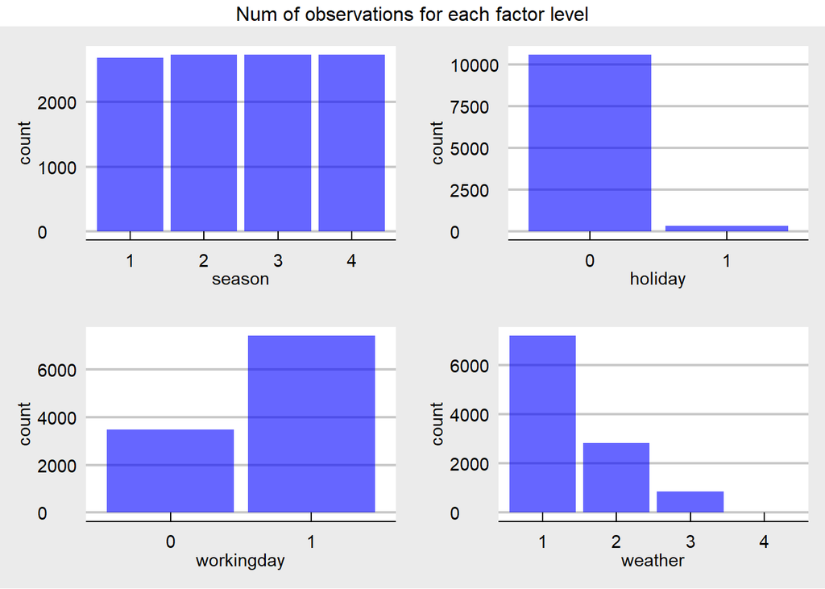

```r
draw.plot1 <- function(data,x,a){
  plt <- data %>% ggplot(aes(x=x)) +
                    geom_bar(fill="blue",alpha=0.6) +
                    labs(x=a) +
                    theme_economist_white()
  return(plt)
}

p1 <- draw.plot1(raw.data,raw.data$season,'season')
p2 <- draw.plot1(raw.data,raw.data$holiday,'holiday')
p3 <- draw.plot1(raw.data,raw.data$workingday,'workingday')
p4 <- draw.plot1(raw.data,raw.data$weather,'weather')

grid.arrange(p1,p2,p3,p4,nrow=2,ncol=2,top="Num of observations for each factor level")
```

#### **Question 2 - How are values of numeric attributes distributed in this dataset?**

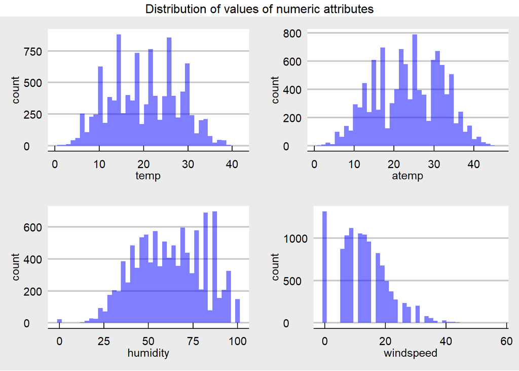

```r
draw.plot2 <- function(data,x,a){
  plt <- data %>% ggplot(aes(x=x)) +
            geom_histogram(bins = 40, fill = "blue", alpha = 0.5) +
            labs(x=a) +
            theme_economist_white()
  return(plt)
}

p1 <- draw.plot2(raw.data,raw.data$temp,"temp")
p2 <- draw.plot2(raw.data,raw.data$atemp,"atemp")
p3 <- draw.plot2(raw.data,raw.data$humidity,"humidity")
p4 <- draw.plot2(raw.data,raw.data$windspeed,"windspeed")

grid.arrange(p1,p2,p3,p4,nrow=2,ncol=2,top="Distribution of values of numeric attributes")
```

From the above graphs we can see that:

- **temp & atemp** - the temperature in this region seems to be mostly in the range of 10deg to 35deg celcius.
- **humidity** - humidity is almost normally distributed except for some peaks at around 80.
- **windspeeds** - windspeeds also seems to be normal mostly except for a few very windy days.

*Overall the dataset seems to suggest pretty normal weather conditions in this region. So it looks like we need not account for any severe weather conditions to predict demand for Bikes at this point of time.*

#### **Question 3 - What is the distribution of outcome variable ih the dataset?**

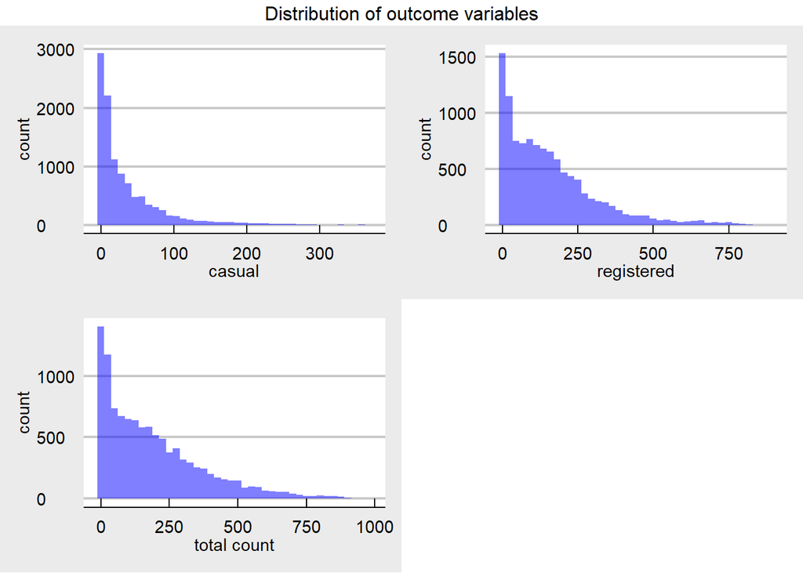

```r
p1 <- draw.plot2(raw.data,raw.data$casual,'casual')
p2 <- draw.plot2(raw.data,raw.data$registered,'registered')
p3 <- draw.plot2(raw.data,raw.data$count,'total count')

grid.arrange(p1,p2,p3,nrow=2,top="Distribution of outcome variables")
```

At first glance this distribution may look a little suspicious, because we see that *casual & registered* have high ‘0’ counts but *total count* does not have as many. But this could be because in cases where casual was 0, registered had some non-zero number, making total count also non-zero and vice-versa.

Let’s just verify that all observations follow the formula *count=casual+registered* just to be sure about the data.

```r
count.verify <- sum((raw.data$casual + raw.data$registered) - raw.data$count)
print(count.verify)
```

```
## [1] 0
```

The count variables in all observations are good to go.

Let’s now look at how the outcome variable is distributed with respect to other variables.

#### **Question 4 - How are Bike hire counts distributed in each month?**

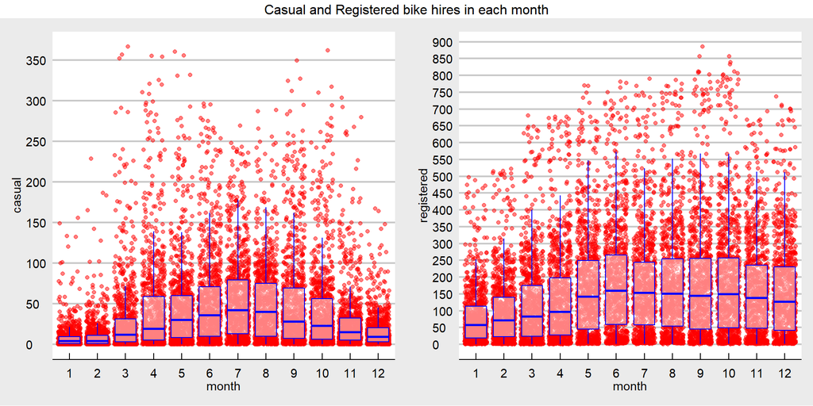

```r
draw.plot3 <- function(data,y,a,y.max){
  plt <- data %>% mutate(month = as.factor(month(datetime))) %>%
                    ggplot(aes(month,y)) +
                      geom_jitter(alpha=0.5,color="red") +
                      geom_boxplot(color="blue",outlier.color=NA,alpha=0.5) +
                      scale_y_continuous(breaks = seq(0,y.max,by=50)) +
                      labs(y=a) +
                      theme_economist_white()
  return(plt)
}

p1 <- draw.plot3(raw.data,raw.data$casual,'casual',500)
p2 <- draw.plot3(raw.data,raw.data$registered,'registered',1000)

grid.arrange(p1,p2,nrow=1,top="Casual and Registered bike hires in each month")
```

First let’s see which month corresponds to which season.

```r
raw.data %>% mutate(month=as.factor(month(datetime))) %>%
              select(season,month) %>%
              distinct()
```

```
##    season month
## 1       1     1
## 2       1     2
## 3       1     3
## 4       2     4
## 5       2     5
## 6       2     6
## 7       3     7
## 8       3     8
## 9       3     9
## 10      4    10
## 11      4    11
## 12      4    12
```

#### **Question 5 - How are Bike hire counts distributed in each season?**

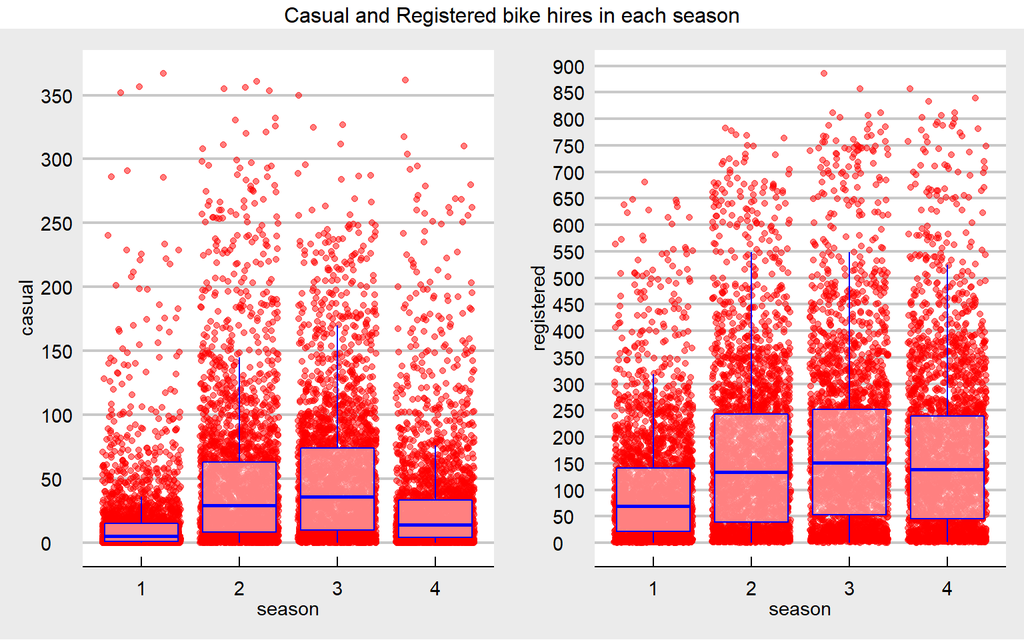

```r
draw.plot4 <- function(data,x,y,a,b,y.max){
  plt <- data %>% ggplot(aes(x=x,y=y)) +
                    geom_jitter(color="red",alpha=0.5) +
                    geom_boxplot(color="blue",alpha=0.5, outlier.color = NA) +
                    labs(x=a,y=b) +
                    scale_y_continuous(breaks = seq(0,y.max,by=50)) +
                    theme_economist_white()
  return(plt)
}

p1 <- draw.plot4(raw.data,raw.data$season,raw.data$casual,'season','casual',500)
p2 <- draw.plot4(raw.data,raw.data$season,raw.data$registered,'season','registered',1000)

grid.arrange(p1,p2,nrow=1, top="Casual and Registered bike hires in each season")
```

#### **Question 6 - How does daily weather affect the number of bike hires?**

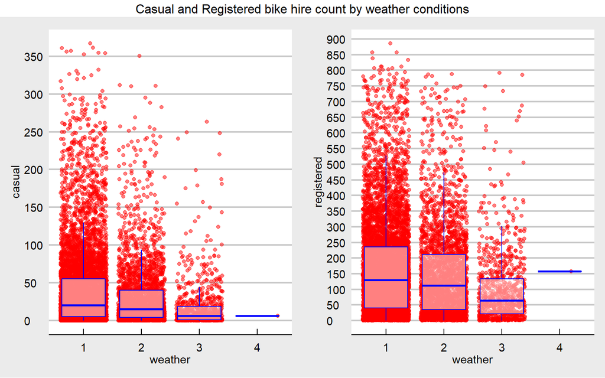

```r
p1 <- draw.plot4(raw.data,raw.data$weather,raw.data$casual,'weather','casual',500)
p2 <- draw.plot4(raw.data,raw.data$weather,raw.data$registered,'weather','registered',1000)

grid.arrange(p1,p2,nrow=1,top="Casual and Registered bike hire count by weather conditions")
```

From the above graphs we can see that both types of users hire fewer bike in **Light Snow + Light Shower** conditions, and the number of hires is negligible when there is **Heavy Snow or Heavy Rain** conditions, which makes sense. However, there seems to be one day in which 150+ bikes were hired by registered users despite severe weather conditions. *It would be good to investigate if this is an anamoly or if there was some issue with data collection*.

#### **Question 7 - How do specific weather conditions such as Temperature, Humidity and Windspeed influence bike hires.?**

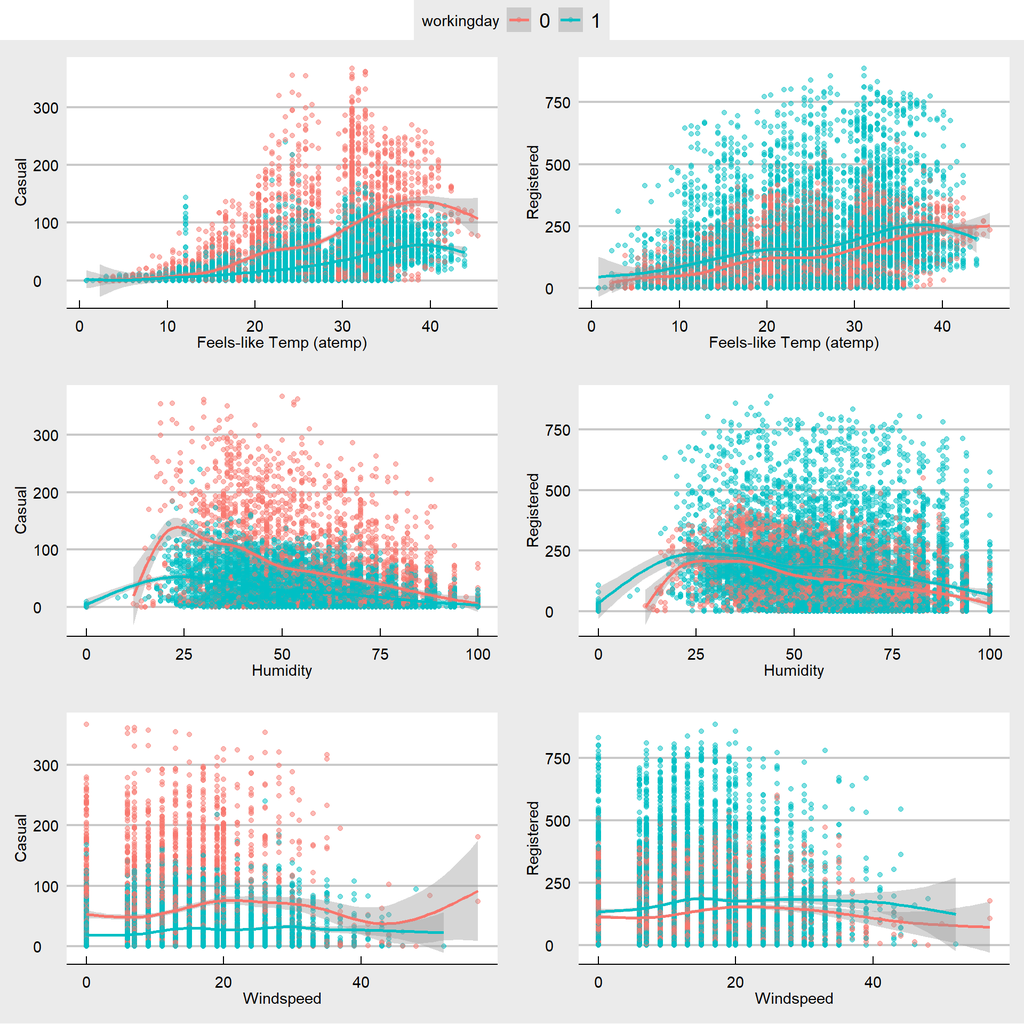

```r
draw.plot5 <- function(data,x,y,a,b){
  plt <- data %>% ggplot(aes(x=x,y=y)) +
                    geom_point(aes(color=workingday),alpha=0.5) +
                    geom_smooth(aes(color=workingday)) +
                    labs(x=a,y=b) +
                    theme_economist_white()
  return(plt)
}

p1 <- draw.plot5(raw.data,raw.data$atemp,raw.data$casual,'Feels-like Temp (atemp)','Casual')
p2 <- draw.plot5(raw.data,raw.data$atemp,raw.data$registered,'Feels-like Temp (atemp)','Registered')
p3 <- draw.plot5(raw.data,raw.data$humidity,raw.data$casual,'Humidity','Casual')
p4 <- draw.plot5(raw.data,raw.data$humidity,raw.data$registered,'Humidity','Registered')
p5 <- draw.plot5(raw.data,raw.data$windspeed,raw.data$casual,'Windspeed','Casual')
p6 <- draw.plot5(raw.data,raw.data$windspeed,raw.data$registered,'Windspeed','Registered')

ggarrange(p1,p2,p3,p4,p5,p6,ncol=2,nrow=3,common.legend = TRUE,legend = 'top')
```

From the above graphs we can see that:

**1. Temperature:** Bike hires by both casual and registered users is low in lower temperatures. There seems to be a positive correlation between temperature and number of hires. However, there is a slight decrease when temperature crosses the 40deg mark. *Temperature could be a variable of interest in predicting bike hires.*

**2. Humidity:** Bike hires by both casual and registered users seems to decrease with increase in humidity. *This could also be an important variable for prediction.*

**3. Windspeed:** Windspeed does not seem to have a lot of impact on number of bike hires by both casual and registered users. However, there seems to be a slight decrease during extremely windy days.

*We can also see that casual riders have hired bikes more on non-working days, where as registered users have hired more on working days. This may be because registered users are using bikes to commute to work and do not use them much on non-working days. So, the company should plan to have more stations near to office areas, if they do not have such an arrangement already.*

Let’s investigate this further.

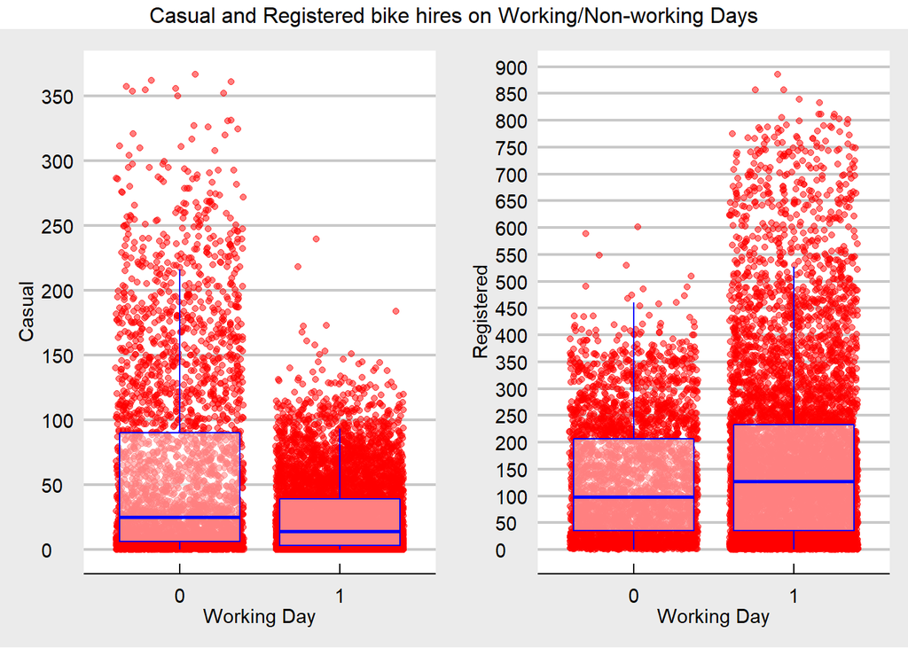

```r
p1 <- draw.plot4(raw.data,raw.data$workingday,raw.data$casual,'Working Day','Casual',1000)
p2 <- draw.plot4(raw.data,raw.data$workingday,raw.data$registered,'Working Day','Registered',1000)

grid.arrange(p1,p2,nrow=1,top="Casual and Registered bike hires on Working/Non-working Days")
```

*The above graphs show that the median hires by registered users is around 125 on working days and slightly less than a 100 on non-working days. Though the difference is not very huge we can see that working days has a broader range.*

*This trend is reversed for casual users. They hire more during non-working days and the range is also broader. The company should track the routes and check if these users and using bike to go to recreational areas such as movies, parks, arenas etc. This could help the company to smartly stack cycles where there is more demand.*

#### **Question 8 - At what time of the day are bikes being hired more?**